# Area Deprivation Index for Pennsylvania 2020

### 4.2 Creation of the ADI for 2020 Pennsylvania

We perform factor analysis to reconstruct the ADI for 2020 Pennsylvania.

```r
# We have to omit NA values before performing factor analysis
merged_data_subset = merged_data[, c("GEOID",vars_demographic)] #include GEOID for now
merged_data_subset_clean <- na.omit(merged_data_subset) #remove NAs

# Perform factor analysis (1-factor solution)
fa_result <- fa(merged_data_subset_clean[,2:18], nfactors = 1, rotate = "varimax")

# Check the factor loadings
fa_result$loadings
```

```
Loadings:
                                 MR1
var_freq_lesshighschool_log      -0.624
var_freq_associates_college       0.776
var_freq_incomplete_plumbing_log -0.166
var_freq_no_telephone_log        -0.265
var_freq_novehicle_log           -0.420
var_freq_overcrowding_log        -0.294
var_freq_poverty_level_log       -0.805
var_freq_poverty_level_150_log   -0.888
var_freq_unemployment_log        -0.338
var_freq_whitecollar              0.792
var_freq_homeownership            0.488
var_freq_singleparent_log        -0.670
var_median_income                 0.885
var_median_rent                   0.627
var_gini                         -0.176
var_home_value                    0.769
var_housing_costs                 0.405

                 MR1
SS loadings    6.179
Proportion Var 0.363
```

```r
# Calculate factor scores for each geographic tract based on the factor analysis
factor_scores <- factor.scores(merged_data_subset_clean[,2:18], fa_result) #Each row corresponds to a geographic tract, and each column corresponds to a factor score coefficient, based on the factors extracted in the factor analysis.
```

We present the data in a table similar to the one for Singh’s data above, in order to facilitate comparison.

```r
# Create the data frame with the characteristics and corresponding factor score coefficients
data_ours <- data.frame(
  Characteristic = c(
    "Percent of the block group’s population aged ≥ 25 years with < 9 years of education",
    "Percent aged ≥ 25 years with an Associate's diploma or higher degree",
    "Percent of employed persons ≥16 years of age in white-collar occupations",
    "Median family income",
    "Income disparity measured by Gini index",
    "Median home value",
    "Median gross rent",
    "Median monthly owner costs",
    "Percent owner-occupied housing units (home ownership rate)",
    "Percent of civilian labor force population ≥ 16 years of age unemployed (unemployment rate), log",
    "Percent of families below the poverty level, log",
    "Percent of population below 150% of the poverty threshold, log",
    "Percent of single-parent households with children < 18 years of age, log",
    "Percent of occupied housing units without a motor vehicle, log",
    "Percent of occupied housing units without a telephone, log",
    "Percent of occupied housing units without complete plumbing, log",
    "Percent of occupied housing units with more than one person per room (crowding), log"
  ),
  Factor_Score_Coefficient = c(
    -0.624, 0.776, 0.792, 0.885, -0.176, 0.769, 0.627, 0.405, 0.488,
-0.338, -0.805, -0.888, -0.670, -0.420, -0.265, -0.166, -0.294
  )
)

# View the table
data_ours |>
  kable(format = "html", col.names = c("Census Block Characteristics", "Factor Score Coefficients")) |>
  kable_styling(
    bootstrap_options = c("striped", "hover", "condensed"),
    full_width = FALSE,
    position = "center"
  ) |>
  column_spec(1, width = "20em") |>
  column_spec(2, width = "10em")
```

| Census Block Characteristics | Factor Score Coefficients |
| --- | --- |
| Percent of the block group’s population aged ≥ 25 years with < 9 years of education | -0.624 |
| Percent aged ≥ 25 years with an Associate's diploma or higher degree | 0.776 |
| Percent of employed persons ≥16 years of age in white-collar occupations | 0.792 |
| Median family income | 0.885 |
| Income disparity measured by Gini index | -0.176 |
| Median home value | 0.769 |
| Median gross rent | 0.627 |
| Median monthly owner costs | 0.405 |
| Percent owner-occupied housing units (home ownership rate) | 0.488 |
| Percent of civilian labor force population ≥ 16 years of age unemployed (unemployment rate), log | -0.338 |
| Percent of families below the poverty level, log | -0.805 |
| Percent of population below 150% of the poverty threshold, log | -0.888 |
| Percent of single-parent households with children < 18 years of age, log | -0.670 |
| Percent of occupied housing units without a motor vehicle, log | -0.420 |
| Percent of occupied housing units without a telephone, log | -0.265 |
| Percent of occupied housing units without complete plumbing, log | -0.166 |
| Percent of occupied housing units with more than one person per room (crowding), log | -0.294 |

We can compare our factor scores to those in Singh’s paper (see Section 3).

We use the factor loadings to compute the ADI for each tract.

```r
adi_scores <- factor_scores$scores[, 1]  # Take the first factor score as the ADI score

# Add the ADI score to the dataset
merged_data_subset_clean$ADI <- adi_scores
```

Plot a map of the ADI in Pennsylvania tracts. We see the distribution of ADI across Pennsylvania; it appears there are regions of higher ADI around the Philadelphia and Pittsburgh areas.

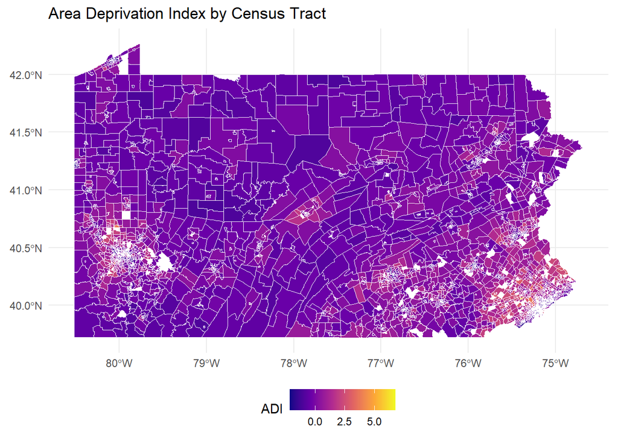

```r
merged_data_subset_clean_map <- pa.tracts |>
  inner_join(merged_data_subset_clean, by = "GEOID")

ggplot(data = merged_data_subset_clean_map) +
  geom_sf(aes(fill = ADI), color = "white", size = 0.2) +
  scale_fill_viridis_c(option = "C") +
  labs(title = "Area Deprivation Index by Census Tract",
       fill = "ADI") +
  theme_minimal() +
  theme(legend.position = "bottom")
```

### 4.3 Test of association between ADI and health outcomes

We test whether the ADI is associated with the five health outcomes of interest.

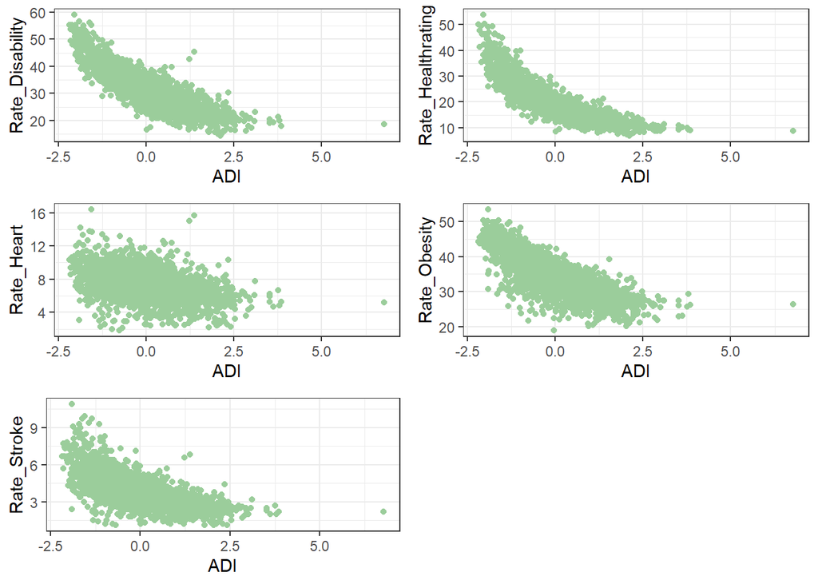

```r
# Combine predictor and outcomes data.
merged_data_all = merged_data_subset_clean |>
  inner_join(merged_outcomes, by = "GEOID")

# Scatter plots
plot_disability = merged_data_all |>
  ggplot(aes(x = ADI, y = Rate_Disability)) +
  geom_point(color = "darkseagreen3") +
  theme_bw()

plot_healthrating = merged_data_all |>
  ggplot(aes(x = ADI, y = Rate_Healthrating)) +
  geom_point(color = "darkseagreen3") +
  theme_bw()

plot_heart = merged_data_all |>
  ggplot(aes(x = ADI, y = Rate_Heart)) +
  geom_point(color = "darkseagreen3") +
  theme_bw()

plot_obesity = merged_data_all |>
  ggplot(aes(x = ADI, y = Rate_Obesity)) +
  geom_point(color = "darkseagreen3") +
  theme_bw()

plot_stroke = merged_data_all |>
  ggplot(aes(x = ADI, y = Rate_Stroke)) +
  geom_point(color = "darkseagreen3") +
  theme_bw()

# Combine the plots into one graphic
grid.arrange(plot_disability, plot_healthrating, plot_heart, plot_obesity, plot_stroke, ncol = 2)
```

There do seem to be linear associations, although the association between ADI and self-reported health seems a little less linear than the others, and the association between ADI and coronary heart disease seems weaker than for the other variables.

We therefore quantify the associations using the Pearson correlation.

```r
# Calculate correlations
cor_results <- tibble(
  Outcome = c("Rate_Disability", "Rate_Healthrating", "Rate_Heart", "Rate_Obesity", "Rate_Stroke"),
  Correlation = c(
    cor(merged_data_all$ADI, merged_data_all$Rate_Disability, use = "complete.obs"),
    cor(merged_data_all$ADI, merged_data_all$Rate_Healthrating, use = "complete.obs"),
    cor(merged_data_all$ADI, merged_data_all$Rate_Heart, use = "complete.obs"),
    cor(merged_data_all$ADI, merged_data_all$Rate_Obesity, use = "complete.obs"),
    cor(merged_data_all$ADI, merged_data_all$Rate_Stroke, use = "complete.obs")
  )
)

# View the results
cor_results
```

```
# A tibble: 5 × 2
  Outcome           Correlation
  <chr>                   <dbl>
1 Rate_Disability        -0.856
2 Rate_Healthrating      -0.841
3 Rate_Heart             -0.422
4 Rate_Obesity           -0.785
5 Rate_Stroke            -0.677
```

We also use linear regression to test whether ADI is significantly associated with the five health outcomes of interest.

```r
summary(lm(Rate_Disability ~ ADI, data = merged_data_all))
```

```
Call:
lm(formula = Rate_Disability ~ ADI, data = merged_data_all)

Residuals:
     Min       1Q   Median       3Q      Max
-15.5281  -2.0637  -0.0777   1.9115  25.8200

Coefficients:
            Estimate Std. Error t value Pr(>|t|)
(Intercept) 32.18205    0.05980  538.15   <2e-16 ***
ADI         -5.79739    0.06147  -94.32   <2e-16 ***
---
Signif. codes:  0 '***' 0.001 '**' 0.01 '*' 0.05 '.' 0.1 ' ' 1

Residual standard error: 3.405 on 3240 degrees of freedom
Multiple R-squared:  0.733, Adjusted R-squared:  0.7329
F-statistic:  8896 on 1 and 3240 DF,  p-value: < 2.2e-16
```

```r
summary(lm(Rate_Healthrating ~ ADI, data = merged_data_all))
```

```
Call:
lm(formula = Rate_Healthrating ~ ADI, data = merged_data_all)

Residuals:
     Min       1Q   Median       3Q      Max
-11.1688  -2.1715  -0.4766   1.5309  27.1522

Coefficients:
            Estimate Std. Error t value Pr(>|t|)
(Intercept) 19.72088    0.06170  319.64   <2e-16 ***
ADI         -5.60137    0.06342  -88.33   <2e-16 ***
---
Signif. codes:  0 '***' 0.001 '**' 0.01 '*' 0.05 '.' 0.1 ' ' 1

Residual standard error: 3.513 on 3240 degrees of freedom
Multiple R-squared:  0.7066,    Adjusted R-squared:  0.7065
F-statistic:  7802 on 1 and 3240 DF,  p-value: < 2.2e-16
```

```r
summary(lm(Rate_Heart ~ ADI, data = merged_data_all))
```

```
Call:
lm(formula = Rate_Heart ~ ADI, data = merged_data_all)

Residuals:
    Min      1Q  Median      3Q     Max
-6.3327 -0.9065  0.1163  0.9881  9.1377

Coefficients:
            Estimate Std. Error t value Pr(>|t|)
(Intercept)  7.56959    0.02688  281.56   <2e-16 ***
ADI         -0.73251    0.02763  -26.51   <2e-16 ***
---
Signif. codes:  0 '***' 0.001 '**' 0.01 '*' 0.05 '.' 0.1 ' ' 1

Residual standard error: 1.531 on 3240 degrees of freedom
Multiple R-squared:  0.1782,    Adjusted R-squared:  0.178
F-statistic: 702.7 on 1 and 3240 DF,  p-value: < 2.2e-16
```

```r
summary(lm(Rate_Obesity ~ ADI, data = merged_data_all))
```

```
Call:
lm(formula = Rate_Obesity ~ ADI, data = merged_data_all)

Residuals:
     Min       1Q   Median       3Q      Max
-15.8205  -1.7764   0.1446   2.0217  20.2624

Coefficients:
            Estimate Std. Error t value Pr(>|t|)
(Intercept) 34.42434    0.05607  613.90   <2e-16 ***
ADI         -4.15779    0.05764  -72.14   <2e-16 ***
---
Signif. codes:  0 '***' 0.001 '**' 0.01 '*' 0.05 '.' 0.1 ' ' 1

Residual standard error: 3.193 on 3240 degrees of freedom
Multiple R-squared:  0.6163,    Adjusted R-squared:  0.6162
F-statistic:  5204 on 1 and 3240 DF,  p-value: < 2.2e-16
```

```r
summary(lm(Rate_Stroke ~ ADI, data = merged_data_all))
```

```
Call:
lm(formula = Rate_Stroke ~ ADI, data = merged_data_all)

Residuals:
    Min      1Q  Median      3Q     Max
-3.3984 -0.4432 -0.0134  0.3669  5.5747

Coefficients:
            Estimate Std. Error t value Pr(>|t|)
(Intercept)  3.83964    0.01454  264.07   <2e-16 ***
ADI         -0.78271    0.01495  -52.37   <2e-16 ***
---
Signif. codes:  0 '***' 0.001 '**' 0.01 '*' 0.05 '.' 0.1 ' ' 1

Residual standard error: 0.8279 on 3240 degrees of freedom
Multiple R-squared:  0.4584,    Adjusted R-squared:  0.4583
F-statistic:  2743 on 1 and 3240 DF,  p-value: < 2.2e-16
```

In simple linear regression models, ADI is significantly associated with rates of disability ($\beta$ = -5.8, p<2e-16), coronary heart disease ($\beta$ = -0.7, p<2e-16), obesity ($\beta$ = -4.2, p<2e-16), stroke ($\beta$ = -0.8, p<2e-16), and self-reported health ($\beta$ = -5.6, p<2e-16).

## 5 Conclusion

In this project, we analyzed the 17 characteristics that Singh used to create the ADI. Whereas he used data from across the United States of America between the years 1969 and 1998, we used data from Pennsylvania 2016-2020. In this way we analyzed whether the 17 characteristics he used are still useful in our population. We successfully replicated Singh’s methods to create an ADI using factor score analysis for Pennsylvania 2020. We then demonstrated that the ADI we devised is significantly correlated with health outcomes including rates of disability, coronary heart disease, obesity, stroke, and self-reported health. Therefore, our ADI appears to be a useful measure for health disparities research in Pennsylvania in the 2020s.

Data missingness, though low, is a limitation of our analyses. In addition, for some of the sociodemographic variables, it is impossible to use the exact variable that Singh used in our modern analyses; for example, income disparity cannot be measured in the exact same way several decades later.

There are many potential future directions for this research.

- To compare the associations between Singh’s ADI and our ADI with health outcomes measures
- To test the association between our ADI and mortality, and other important health outcomes measures
- To investigate other sociodemographic characteristics that may be useful in an ADI, and consider whether these should be in addition to or instead of characteristics currently in the ADI; some additional characteristics to consider are included in the Supplements section.
- To re-examine the ADI using 2020 data for the entire country, and state-by-state, and test whether the measurements do differ significantly by state; in this way, we can decide whether there should be different ADIs for each state or whether it is sufficient to have one country-wide

Overall, our ADI is a useful measure for health disparities research in Pennsylvania in the 2020s, and significantly associated with important health outcomes measures.

## 6 References

[output not shown]

## 7 Supplement

These are some additional variables that may be of interest to study and potentially incorporate in future ADIs.

```r
## race
vars_dhc_race = c(
        #all = "P3_001N",
        white = "P3_002N",
        baa = "P3_003N",
        amin = "P3_004N",
        asian = "P3_005N",
        nhopi = "P3_006N",
        other = "P3_007N",
        multi = "P3_008N"
       )

data_dhc_race = get_decennial(
  geography = "tract",
  state = "PA",
  variables = vars_dhc_race,
  summary_var = "P3_001N", #creates a column w/'total' variable
  year = 2020,
  sumfile = "dhc"
)
```

```
Using the Demographic and Housing Characteristics File
```

```r
#create a column with frequency
data_dhc_race <- data_dhc_race |>
  mutate(var_freq_race = ifelse(summary_value != 0, value / summary_value, NA))
#remove variable list
rm(vars_dhc_race)

## ethnicity
vars_dhc_ethnicity = c(
        #all = "P4_001N",
        nothisp = "P4_002N", #Not Hispanic or Latino
        hisp = "P4_003N" #Hispanic or Latino
       )

data_dhc_ethnicity = get_decennial(
  geography = "tract",
  state = "PA",
  variables = vars_dhc_ethnicity,
  summary_var = "P4_001N", #creates a column w/'total' variable
  year = 2020,
  sumfile = "dhc"
)
```

```
Using the Demographic and Housing Characteristics File
```

```r
data_dhc_ethnicity <- data_dhc_ethnicity |>
  mutate(var_freq_ethnicity = ifelse(summary_value != 0, value / summary_value, NA))
rm(vars_dhc_ethnicity)

## urban/rural
vars_dhc_urban_p = c(
        #all = "P2_001N",
        urban = "P2_002N",
        rural = "P2_003N",
        urbanrural_undefined = "P2_004N" #Not defined for this file
       )

data_dhc_urban_p = get_decennial(
  geography = "tract",
  state = "PA",
  variables = vars_dhc_urban_p,
  summary_var = "P2_001N", #creates a column w/'total' variable
  year = 2020,
  sumfile = "dhc"
)
```

```
Using the Demographic and Housing Characteristics File
```

```r
data_dhc_urban_p <- data_dhc_urban_p |>
  mutate(var_freq_urban = ifelse(summary_value != 0, value / summary_value, NA))
rm(vars_dhc_urban_p)

## housing units occupied
vars_dhc_housing_occ = c(
        #all = "H3_001N",
        housing_occupied = "H3_002N",
        housing_vacant = "H3_003N"
        )

data_dhc_housing_occ = get_decennial(
  geography = "tract",
  state = "PA",
  variables = vars_dhc_housing_occ,
  summary_var = "H3_001N", #creates a column w/'total' variable
  year = 2020,
  sumfile = "dhc"
)
```

```
Using the Demographic and Housing Characteristics File
```

```r
data_dhc_housing_occ <- data_dhc_housing_occ |>
  mutate(var_freq_housing_occ = ifelse(summary_value != 0, value / summary_value, NA))
rm(vars_dhc_housing_occ)

## household type
#NOTE: A household that has at least one member of the household related to the householder by birth, marriage, or adoption is a "Family household." "Nonfamily households" consist of people living alone and households which do not have any members related to the householder.
vars_dhc_household_type = c(
        #all = "P16_001N",
        married = "P16_003N", #Family households: Married couple family
        householder_male = "P16_005N", #Family households: Male householder, no spouse present
        householder_female = "P16_006N", #Family households: Female householder, no spouse present
        householder_alone = "P16_008N", #Nonfamily households: Householder living alone
        householder_not_alone = "P16_009N" #Nonfamily households: Householder not living alone
       )

data_dhc_household_type = get_decennial(
  geography = "tract",
  state = "PA",
  variables = vars_dhc_household_type,
  summary_var = "P16_001N", #creates a column w/'total' variable
  year = 2020,
  sumfile = "dhc"
)
```

```
Using the Demographic and Housing Characteristics File
```

```r
data_dhc_household_type <- data_dhc_household_type |>
  mutate(var_freq_household_type = ifelse(summary_value != 0, value / summary_value, NA))
rm(vars_dhc_household_type)

## household size
vars_dhc_household_size = c(
       #all = "H9_001N",
        household_one = "H9_002N", #1-person household
        household_two = "H9_003N", #2-person household
        household_three = "H9_004N", #3-person household
        household_four = "H9_005N", #4-person household
        household_five = "H9_006N", #5-person household
        household_six = "H9_007N", #6-person household
        household_seven = "H9_008N" #7-person household
        )

data_dhc_household_size = get_decennial(
  geography = "tract",
  state = "PA",
  variables = vars_dhc_household_size,
  summary_var = "H9_001N", #creates a column w/'total' variable
  year = 2020,
  sumfile = "dhc"
)
```

```
Using the Demographic and Housing Characteristics File
```

```r
data_dhc_household_size <- data_dhc_household_size |>
  mutate(var_freq_household_size = ifelse(summary_value != 0, value / summary_value, NA))
rm(vars_dhc_household_size)


## median age
vars_dhc_median_age = c(
        age_median = "P13_001N"
        )

data_dhc_median_age = get_decennial(
  geography = "tract",
  state = "PA",
  variables = vars_dhc_median_age,
  year = 2020,
  sumfile = "dhc"
)
```

```
Using the Demographic and Housing Characteristics File
```

```r
rm(vars_dhc_median_age)


## income
vars_acs_income = c(
        #all = "B19001_001", #HOUSEHOLD INCOME IN THE PAST 12 MONTHS (IN 2020 INFLATION-ADJUSTED DOLLARS)
        income_under10k = "B19001_002", #Less than $10,000
        income_10_add5 = "B19001_003", #$10,000 to $14,999
        income_15_add5 = "B19001_004", #$15,000 to $19,999
        income_20_add5 = "B19001_005", #$20,000 to $24,999
        income_25_add5 = "B19001_006", #$25,000 to $29,999
        income_30_add5 = "B19001_007", #$30,000 to $34,999
        income_35_add5 = "B19001_008", #$35,000 to $39,999
        income_40_add5 = "B19001_009", #$40,000 to $44,999
        income_45_add5 = "B19001_010", #$45,000 to $49,999
        income_50_add10 = "B19001_011", #$50,000 to $59,999
        income_60_add15 = "B19001_012", #$60,000 to $74,999
        income_75_add25 = "B19001_013", #$75,000 to $99,999
        income_100_add25 = "B19001_014", #$100,000 to $124,999
        income_125_add25 = "B19001_015", #$125,000 to $149,999
        income_150_add50 = "B19001_016", #$150,000 to $199,999
        income_above200 = "B19001_017" #$200,000 or more
        )

data_acs_income = get_acs(
  geography = "tract",
  state = "PA",
  variables = vars_acs_income,
  summary_var = "B19001_001", #creates a column w/'total' variable
  year = 2020
)
# Summarize the data
data_acs_income <- data_acs_income |>
  mutate(category = case_when(
    variable %in% "income_under10k" ~ "income_under10k",
    variable %in% c("income_50_add10", "income_60_add15", "income_75_add25", "income_100_add25" , "income_125_add25", "income_150_add50", "income_above200") ~ "income50kandup",
    TRUE ~ NA_character_  # Handle cases that do not fall into these categories
  ))

data_acs_income_combined <- data_acs_income |>
  group_by(GEOID, category) |>
  summarise(
    estimate = sum(estimate, na.rm = TRUE),
    summary_est = first(summary_est),  # Assuming summary_est is the same for each group
    var_freq_income = estimate / summary_est,
    .groups = 'drop'
  )
rm(vars_acs_income)
```